# GEOG 5680 6680 08 Data manipulation with dplyr

Simon Brewer Geography Department University of Utah

13 May, 2024

# Introduction

Before starting, remember to create a working directory (e.g. `module08`). Next download the files for today’s lab from the Canvas page and move them to this directory. You’ll need the following file:

- *gapminderData5.csv*

Then start RStudio, and change your working directory from the [Session] menu > [Set working directory] > [Choose directory…]. Remember to check that R can see the files by running the `list.files()` command.

In this lab, we will look at the add-on package **dplyr**. This is a powerful R-package to transform and summarize tabular data with rows and columns. The package contains a set of functions (or “verbs”) that perform common data manipulation operations such as filtering for rows, selecting specific columns, re-ordering rows, adding new columns and summarizing data. (This lab borrows heavily from Rafael Irizarry and Michael Love’s [blog](http://genomicsclass.github.io/book/pages/dplyr_tutorial.html))

These functions are designed to replace the base R functions that we have worked with so far, such as `subset()`, `apply()`, `sapply()`, `lapply()`, `tapply()` and `aggregate()`. Compared to base functions in R, the functions in **dplyr** are easier to work with, are more consistent in the syntax and are targeted for data analysis around data frames instead of just vectors.

Start by downloading and installing **dplyr** using the `install.packages()` function (or the package menu in RStudio). Once installed, load the package:

```r
library(dplyr)
```

We’ll also load the [GapMinder](https://www.gapminder.org) dataset to use in our examples.

```r
gap <- read.csv("gapminderData5.csv")
str(gap)
head(gap)
```

# Important dplyr verbs

**dplyr** has a wide variety of operations, but the most important ones are:

| Verb | Description |
| --- | --- |
| `select()` | select columns |
| `filter()` | filter rows |
| `arrange()` | re-order or arrange rows |
| `mutate()` | create new columns |
| `summarise()` | summarize values |
| `group_by()` | allows for group operations |

## Selecting by column

The `select()` function allows the selection of columns by name:

```r
gap_gdp <- select(gap, country, gdpPercap)
head(gap_gdp)
```

```
##       country gdpPercap
## 1 Afghanistan  779.4453
## 2 Afghanistan  820.8530
## 3 Afghanistan  853.1007
## 4 Afghanistan  836.1971
## 5 Afghanistan  739.9811
## 6 Afghanistan  786.1134
```

To select all the columns except a specific column, use the “-” (subtraction) operator:

```r
gap_nogdp <- select(gap, -gdpPercap)
head(gap_nogdp)
```

To select a range of columns by name, use the “`:`” (colon) operator (as we did with selecting multiple columns using indices)

```r
gap_sub <- select(gap, country:continent)
head(gap_sub)
```

To select all columns that start with the character string “co”, use the function `starts_with()`

```r
select(gap, starts_with("co"))
```

Here are some additional functions to select columns based on a specific criteria:

- `ends_with()` = Select columns that end with a character string
- `contains()` = Select columns that contain a character string
- `matches()` = Select columns that match a regular expression
- `one_of()` = Select columns names that are from a group of names

## Selecting by row

The `filter()` function allows the selection of rows. To filter the data for rows where the life expectancy is over 65 years:

```r
filter(gap, lifeExp > 65)
```

To filter for rows where the life expectancy is over 65 and the continent is Africa

```r
filter(gap, lifeExp > 65, continent == "Africa")
```

To filter for rows where the life expectancy is over 65 and the continent is Africa and the year is 2007:

```r
filter(gap, lifeExp > 65, continent == "Africa", year == 2007)
```

Filter for countries from America and Europe:

```r
filter(gap, continent %in% c("America","Europe"))
```

Note that there is also a `slice()` function, which simply extracts rows according to their position - this is the equivalent to the indexing we have done before:

```r
slice(gap, 20:25)
```

```
##   country year     pop continent lifeExp gdpPercap
## 1 Albania 1987 3075321    Europe  72.000  3738.933
## 2 Albania 1992 3326498    Europe  71.581  2497.438
## 3 Albania 1997 3428038    Europe  72.950  3193.055
## 4 Albania 2002 3508512    Europe  75.651  4604.212
## 5 Albania 2007 3600523    Europe  76.423  5937.030
## 6 Algeria 1952 9279525    Africa  43.077  2449.008
```

## The pipe operator

The package **magrittr** has a pipe operator which we can use to start to chain together **dplyr** functions. This is loaded automatically with **dplyr** so you don’t need to worry about loading it. The pipe operator is written as `%>%`, and takes the output from one function and *pipes* it directly to another function. So in the very first example of the `select()` function, we used select to obtain some columns from the data frame then used `head()` to examine the first few rows:

```r
gap_gdp <- select(gap, country, gdpPercap)
head(gap_gdp)
```

We can rewrite this as a single line using `%>%` and avoiding the need for the intermediate data frame `gap_gdp`:

```r
gap %>% select(country, gdpPercap) %>% head()
```

```
##       country gdpPercap
## 1 Afghanistan  779.4453
## 2 Afghanistan  820.8530
## 3 Afghanistan  853.1007
## 4 Afghanistan  836.1971
## 5 Afghanistan  739.9811
## 6 Afghanistan  786.1134
```

Note that for clarity, this is usually written across several lines:

```r
gap %>%
  select(country, gdpPercap) %>%
  head()
```

## The `arrange()` function

This function allows us to arrange (or re-order) rows by a particular column. So to arrange by increasing life expectancy (you can remove the `head()` function to see all the output):

```r
gap %>%
  arrange(lifeExp) %>%
  head()
```

```
##        country year     pop continent lifeExp gdpPercap
## 1       Rwanda 1992 7290203    Africa  23.599  737.0686
## 2  Afghanistan 1952 8425333      Asia  28.801  779.4453
## 3       Gambia 1952  284320    Africa  30.000  485.2307
## 4       Angola 1952 4232095    Africa  30.015 3520.6103
## 5 Sierra Leone 1952 2143249    Africa  30.331  879.7877
## 6  Afghanistan 1957 9240934      Asia  30.332  820.8530
```

Now, we will select four columns from the dataset, arrange the rows by the life expectancy then pass this to `head()` to show the first few rows:

```r
gap %>%
  select(country, year, lifeExp, gdpPercap) %>%
  arrange(lifeExp) %>%
  head()
```

Now do the same, but only filter for the year 2002

```r
gap %>%
  select(country, year, lifeExp, gdpPercap) %>%
  filter(year == 2002) %>%
  arrange(lifeExp) %>%
  head()
```

Or to do the same, but ordered by GDP:

```r
gap %>%
  select(country, year, lifeExp, gdpPercap) %>%
  filter(year == 2002) %>%
  arrange(gdpPercap) %>%
  head()
```

Repeat this, but sort the GDP in descending order. For this, we can use the function `desc()`:

```r
gap %>%
  select(country, year, lifeExp, gdpPercap) %>%
  filter(year == 2002) %>%
  arrange(desc(gdpPercap)) %>%
  head()
```

Note that all this output so far is simply being dumped to the screen. If you want to save the output for further use, we need to assign the operator to a new variable (data frame). The following creates a new data frame, with the sorted information for 2002:

```r
gap2002 <- gap %>%
  select(country, year, lifeExp, gdpPercap) %>%
  filter(year == 2002) %>%
  arrange(desc(gdpPercap))
```

## The `distinct()` function

The function `distinct()` will return the unique values of a vector, so to get the list of countries in the GapMinder data set

```r
gap %>%
  distinct(country)
```

```r
gap %>%
  filter(lifeExp < 35) %>%
  distinct(country)
```

## The `mutate()` function

This function can be used to add new columns to the data frame. We’ll use this to create a new column of total country GDP, which is per capita GDP multiplied by the population

```r
gap %>%
  mutate(gdp = gdpPercap*pop)
```

And let’s sort by this to find the country and year with the highest total GDP

```r
gap %>%
  mutate(gdp = gdpPercap*pop) %>%
  arrange(desc(gdp)) %>%
  head()
```

## The `summarize()` function

This function will create summary statistics for a given column in the data frame, for example, finding the mean. To compute the average life expectancy, use the `mean()` function with the column `lifeExp`:

```r
gap %>%
    summarise(avgLE = mean(lifeExp))
```

```
##      avgLE
## 1 59.47444
```

You can use most of the functions we have previously looked at for creating summary statistics, including `sd()`, `min()`, `max()`, `median()`, `sum()`. In addition, `n()` returns the length of the vector, `first()` returns the first value in vector, `last()` returns the last value in vector and `n_distinct()` returns the number of distinct values in vector. We can then easily set up a function to calculate a range of summary statistics as follows:

```r
gap %>%
    summarise(avgLE = mean(lifeExp),
              sdLE = sd(lifeExp),
              minLE = min(lifeExp),
              maxLE = max(lifeExp))
```

```
##      avgLE     sdLE  minLE  maxLE
## 1 59.47444 12.91711 23.599 82.603
```

## The `group_by()` function

The `group_by()` function is a very useful addition to these other functions. It is related to concept of “split-apply-combine”, that for many analyses, we literally want to split the data frame by some variable (e.g. country or year), apply a function to the individual data frames and then combine the output.

Let’s do that: split the GapMinder data frame by country, calculate summary statistics (as above), then return everything in a new data frame, giving a set of summary statistics for each country.

```r
gap %>%
  group_by(country) %>%
  summarise(avgLE = mean(lifeExp),
              sdLE = sd(lifeExp),
              minLE = min(lifeExp),
              maxLE = max(lifeExp))
```

```
## # A tibble: 142 × 5
##    country     avgLE  sdLE minLE maxLE
##    <chr>       <dbl> <dbl> <dbl> <dbl>
##  1 Afghanistan  37.5  5.10  28.8  43.8
##  2 Albania      68.4  6.32  55.2  76.4
##  3 Algeria      59.0 10.3   43.1  72.3
##  4 Angola       37.9  4.01  30.0  42.7
##  5 Argentina    69.1  4.19  62.5  75.3
##  6 Australia    74.7  4.15  69.1  81.2
##  7 Austria      73.1  4.38  66.8  79.8
##  8 Bahrain      65.6  8.57  50.9  75.6
##  9 Bangladesh   49.8  9.03  37.5  64.1
## 10 Belgium      73.6  3.78  68    79.4
## # ℹ 132 more rows
```

And finally, let’s sort the output by average life expectancy over the GapMinder observation period:

```r
gap %>%
  group_by(country) %>%
  summarise(avgLE = mean(lifeExp),
              sdLE = sd(lifeExp),
              minLE = min(lifeExp),
              maxLE = max(lifeExp)) %>%
  arrange(avgLE)
```

# **dplyr** and **ggplot2**

The **dplyr** package integrates nicely with the **ggplot2** function (they were both largely written by the same person). So we can use the same process based on pipes to subset a data frame, and pass the output directly to the `ggplot()` function. For example, to extract the time series of GDP for the United States and plot this as a line graph (first load **ggplot2**):

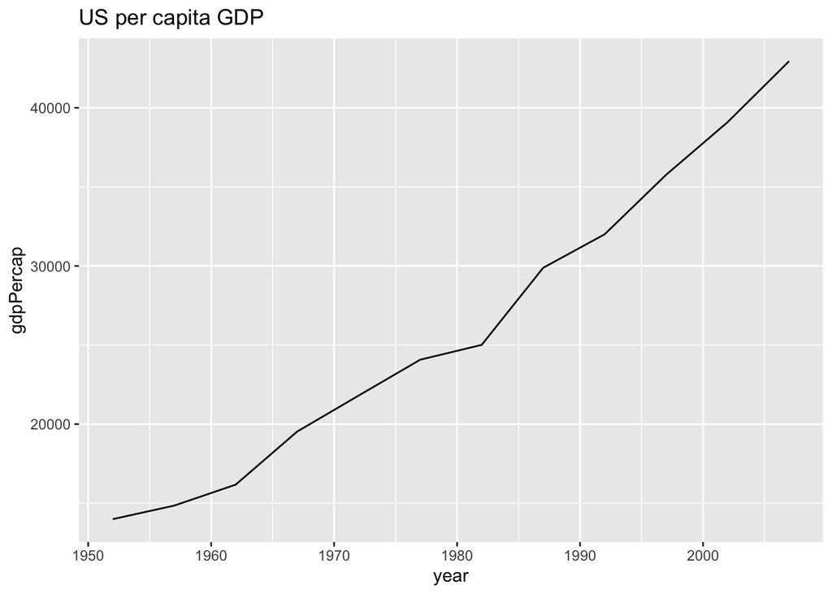

```r
library(ggplot2)
gap %>%
  filter(country=="United States") %>%
  ggplot(aes(x=year, y=gdpPercap)) + geom_line() + ggtitle("US per capita GDP")
```

You can extract this information for multiple countries:

```r
gap %>%
  filter(country %in% c("United States", "Germany", "Japan", "China")) %>%
  ggplot(aes(x=year, y=gdpPercap, col=country)) + geom_line()
```

Alternatively, we can get values for a given year, and make histograms by continent:

```r
gap %>%
  filter(year == 1992) %>%
  ggplot(aes(x=lifeExp)) + geom_histogram() + facet_wrap(~continent)
```

# Exercises

The exercise for this lab uses data from the file *theoph.csv*. This contains results from a study on the pharmacokinetics of theophylline, an anti-asthmatic drug. Twelve subjects were given oral doses of theophylline then serum concentrations were measured at 11 time points over the next 25 hours. The variables include the subject ID, their weight, the dose of the drug administered, the time at which samples were drawn and the concentration of the drug.

Download the data, and read it into R. Before starting the exercise, convert the subject ID (`Subject`) to a factor:

```r
theoph$Subject = factor(theoph$Subject)
```

You should submit the results as an R script with the commands you used, and a Word (or equivalent) with the plots. Remember that you can export plots directly from the plot window, or by using `pdf()` to export to a file.

Remember that you can also use R Markdown and **knitr** to produce an html page that contains both the code *and* the plots. If you have the time to do this, I would highly recommend it, as it is a great way to keep all your results in one place.

Now use the commands introduced above to do the following:

- Using `select()` make a new data frame containing only the subject ID, the Time and conc variables
- Using a combination of `select()` and `distinct()` make a new data frame containing a single row for each subject with the subject ID, their weight and the dose
- Using `filter()` make a new data frame containing only the first subject
- Using `filter()` make a new data frame containing only the first *four* subjects
- Using `group_by()`, calculate the average concentration per subject (across all times)
- Using `filter()` make a new data frame containing only the first subject *and* pipe this to `ggplot()` to make a line plot with `Time` on the x-axis and `conc` on the y-axis
- Using `select()` to extract just the `Subject`, `Time` and `conc` variables *and* pipe this to `ggplot()` to make a line plot with `Time` on the x-axis, `conc` on the y-axis and the lines colored by subject
- Using `select()` to extract just the `Subject`, `Time` and `conc` variables *and* pipe this to ggplot to make a line plot with `Time` on the x-axis, `conc` on the y-axis and faceted by the subject ID

# Files used in lab

## *gapminderData5.csv*

GapMinder dataset on global inequality

| Column header | Variable |
| --- | --- |
| country | Country name |
| year | Year |
| pop | Population |
| continent | Continent |
| lifeExp | Life expectancy |
| gdpPercap | Per capita GDP (US$ 2010) |

## *theoph.csv*

Theophylline pharmacokinetic dataset

| Column header | Variable |
| --- | --- |
| Subject | Subject ID |
| Wt | Weight (kg) |
| Dose | Dose of theophylline (mg/kg) |
| Time | Time since dose given (hr) |
| conc | Sample concentration of theophylline (mg/l) |